# Jupyter version of the aging scripts

# Part one. Compile aging lists of genes from source files

Import necessary packages

```python
import matplotlib.pyplot as plt, numpy as np, math, scipy.stats as stats #, skbio.diversity.alpha as sda
```

Define directory where you keep your source files: "mdir" List all files you will import for analysis: "sets" Make shortlists from all signature files: "setnames"

```python
sets=["Beerman_2013.txt","Chambers_2007.txt","Flach_2014.txt","Grover_2016.txt",
    "Kirshner_2017.txt","Kowalczyk_2015.txt","Noda_2009.txt","Quere_2014.txt",
    "Rossi_2005.txt","Sun_2014.txt","Wahlestedt_2013.txt"]
setnames=[x[:-4] for x in sets]
"add  other list to the list of other files"
"extra file for DGSE plot and comparison to others"

mdir="/Users/leonid_bystrykh/Documents/Articles&Presentations/2020/AgingSign/data/meta/"
```

open every file and collect all names of genes names is set of sets, fcs are fold changes per gene allg (all genes) and allf (all found times) are united set with frequencies

```python
names,fcs,allg,allf=[],[],[],[]
for file in sets:
    f_in=open(mdir+ file,'r')
    print(file)
    lines=f_in.readlines()
    na,fc=[],[] #list of genes and frequencies per set
    for line in lines[2:]: #skip first two lines
        items= line.rstrip().replace("'","").replace(" ","").split('\t')
        it=items[1].split('///') #for multiple gene names take the 1st
        if it[0] not in na:
            na.append(it[0]) #0 stands for the 1st column, otherwise change
            fc.append(float(items[2])) #1 stands for the second column
    #count all genes and their frequencies per publication
    for n in na:
        if n not in allg:
            allg.append(n)
            allf.append(1)
        else:
            allf[allg.index(n)]+=1
    names.append(na) #list of lists of gene names
    fcs.append(fc)  #list of lists of fold changes
    f_in.close()
```

```
Beerman_2013.txt
Chambers_2007.txt
Flach_2014.txt
Grover_2016.txt
Kirshner_2017.txt
Kowalczyk_2015.txt
Noda_2009.txt
Quere_2014.txt
Rossi_2005.txt
Sun_2014.txt
Wahlestedt_2013.txt
```

```python
print("summary")
for i in range(len(sets)):
    print(sets[i],len(names[i]),names[i][:5],"...")
```

```
summary
Beerman_2013.txt 421 ['Btbd2', 'Wwtr1', 'Orai3', 'Sdpr', 'Csgalnact1'] ...
Chambers_2007.txt 2573 ['Mmp2', 'Ap1g2', 'Prkcabp', '4930563C04Rik', 'Ppan'] ...
Flach_2014.txt 888 ['Tdrd9', 'Gpr183', 'Zg16', 'Trpc1', 'Gpatch8'] ...
Grover_2016.txt 60 ['Sdpr', 'Nupr1', 'Btg2', 'Ddx3y', 'Mt1'] ...
Kirshner_2017.txt 62 ['Hes1', 'Btg2', 'Nr4a2', 'Nr4a1', 'Skil'] ...
Kowalczyk_2015.txt 77 ['Nupr1', 'Sult1a1', 'Apoe', 'Clec1a', 'Sdpr'] ...
Noda_2009.txt 155 ['1190002H23Rik', 'Apbb2', 'Cadm1', 'Cdkn1a', 'Cdkn2c'] ...
Quere_2014.txt 204 ['Sdpr', 'Cd28', 'Ctla4', 'Wnt10a', 'Cxcr7'] ...
Rossi_2005.txt 737 ['Lpl', 'Scd1', 'Hist1h1c', 'Cyp4b1', 'Crk'] ...
Sun_2014.txt 2634 ['Fosb', 'Col1a1', 'Tdrd9', 'Gm106', 'Gpr183'] ...
Wahlestedt_2013.txt 408 ['Lpl', 'Npdc1', 'Scd1', 'Sgk1', 'Perp'] ...
```

```python
allfcs=[] #all fold changes
for gene in allg:
    folds=[]
    for i in range(len(names)):
        for j in range(len(names[i])):
            if gene==names[i][j]:
                folds.append(fcs[i][j])
    allfcs.append(folds)
```

Now we can save the data in the Aging List file (which is named here as "rean_gene_fcs_META.txt". We will save average of all fold changes. We can also save all fold changes as a list in a separate column, if we want. To do so just add allfcs[i] as separate column in f_out.writelines() line

```python
f_out=open("rean_gene_fcs_META.txt","w")
f_out.writelines("Gene\tFreq_group\tLog2FC\n")

for i in range(len(allg)):
   # print(allg[i],allf[i], allfcs[i])
    f_out.writelines(allg[i]+"\t"+str(allf[i])+"\t"+str(sum(allfcs[i])/len(allfcs[i]))+"\n")
f_out.close()
```

In principle, the Aging List is the most important part of the scipt. You can stop here and proceed with the next script for further study and use of the aging signature. Below are some additional files which you can use if you want it. Here is a cross-comparison of all files used for the list.

```python
print("table of intersects\t set_size\t Intersects_tab\t all_intersected\t nr_intersected\t fraction_intersected")
s,v,u,dists=[],[],[],[] # u for unique genes
for i in range(len(names)):
    val,uni=[],[]
    "define pos, neg"
    for j in range(len(names)):
        ovl=[x for x in names[i] if x in names[j]]
        if i!=j:
            val.append(len(ovl))
            for o in ovl:
                if o not in uni:
                    uni.append(o)
        else:
            self=len(ovl) #dirty trick for own size
            val.append(0)
    u.append(uni)
    s.append(self)
    dists.append(val)
    v.append(len(uni)) #length unique list
    print(sets[i],self,val,sum(val),len(uni), len(uni)/self, sep="\t")
```

[output not shown]

The table above can be presented as a heatmap below

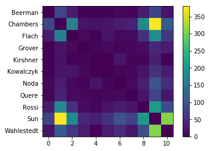

```python
#heatmap figure for similarities between gene sets
plt.imshow(dists)
plt.yticks(range(len(setnames)),setnames)
plt.colorbar()
#plt.show()
```

Scatter plot can be skipped At the end some summary table for each file used for the Aging List

```python
#plot of gene frequencies
#plt.plot(freqs,counts, 'o-')
#plt.scatter(freqs,counts)
#plt.show()

print("make groups of genes by their frequencies of occurrence")
print("per set")
print("set\ttotal\t>3\t relative") #\t p_hypergeometric
for val in range(len(sets)):
    total,sig=len(names[val]),0
    for name in names[val]:
        if name in allg:
            score=allf[allg.index(name)]
            if score>3:
                sig+=1
    print(sets[val], total, sig, float(sig)/float(total), sep="\t") #myp,
```

[output not shown]